# solution

name

2018/4/28

Accodding to the help document of Highway1 data in R, the data comes from a unpublished master’s paper by Carl Hoffstedt. They relate the automobile accident rate, in accidents per million vehicle miles to several potential terms. The data include 39 sections of large highways in the state of Minnesota in 1973. The goal of this analysis was to understand the impact of design variables, **Acpts**, **Slim**, **Sig**, and **Shld** that are under the control of the highway department, on accidents. Before beginning our analysis, we need to do log transfrom to some of the variables.

```r
# options(warn = -1)
# load package
library(carData)
library(dplyr)
library(leaps)

# response
# rate
#
# variables which is interested in
#
# acpt
# slim
# sigs1
# shld

# log transform of some variables and response of Highway1 data set
logTrans <- c('acpt','slim','sigs1','shld','rate')
# log tran  sform
Highway1[,logTrans] <- log(Highway1[,logTrans])

# structure of Highway1 data set
str(Highway1)
```

```
## 'data.frame':    39 obs. of  12 variables:
##  $ rate : num  1.522 1.051 1.105 0.829 0.476 ...
##  $ len  : num  4.99 16.11 9.75 10.65 20.01 ...
##  $ adt  : int  69 73 49 61 28 30 46 25 43 23 ...
##  $ trks : int  8 8 10 13 12 6 8 9 12 7 ...
##  $ sigs1: num  -1.61 -2.78 -2.28 -2.37 -3 ...
##  $ slim : num  4.01 4.09 4.09 4.17 4.25 ...
##  $ shld : num  2.3 2.3 2.3 2.3 2.3 ...
##  $ lane : int  8 4 4 6 4 4 4 4 4 4 ...
##  $ acpt : num  1.526 1.482 1.548 1.335 0.788 ...
##  $ itg  : num  1.2 1.43 1.54 0.94 0.65 0.34 0.47 0.38 0.95 0.12 ...
##  $ lwid : int  12 12 12 12 12 12 12 12 12 12 ...
##  $ htype: Factor w/ 4 levels "FAI","MA","MC",..: 1 1 1 1 1 4 4 4 4 4 ...
```

the scatter plot matrix suggests some correlation between the covariates and response, both the positive and negative relationships.

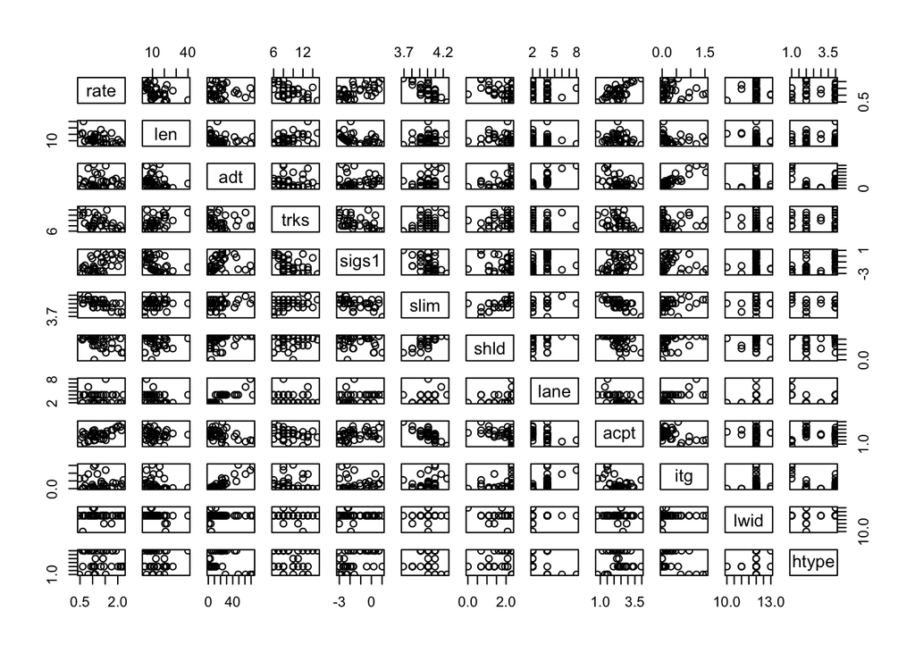

```r
plot(Highway1)
```

In paticular, we draw a plot including four scatterplots of rate and the four variables saparately. From overall view, there seem be a positive correlation between rate and acpt,sigs1, and a negative correlation between rate and slim,shld.

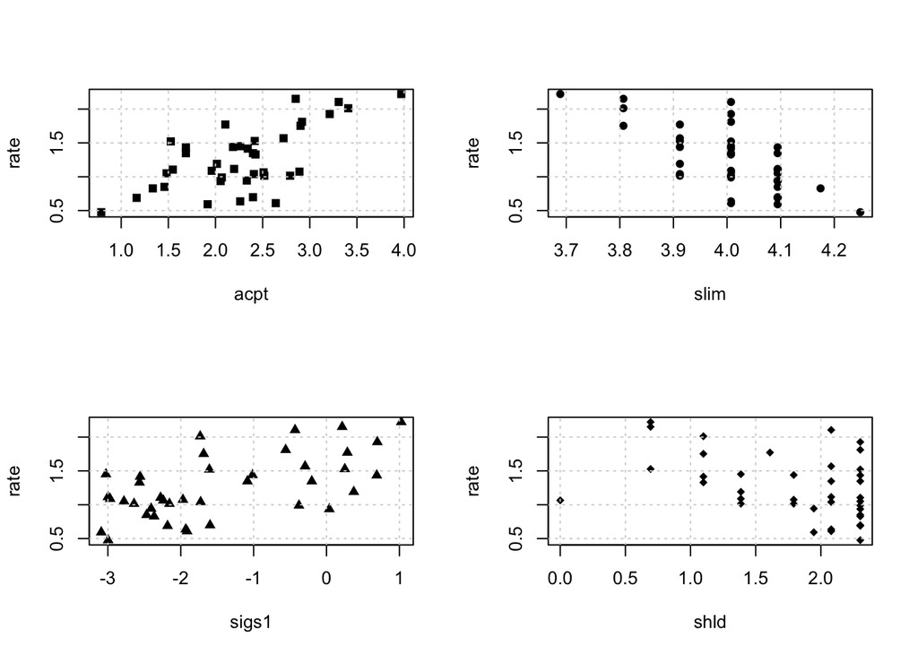

```r
# scatterplot of response and four interested variables
par(mfrow = c(2,2))
plot(rate ~ acpt, data = Highway1, pch = 15); grid()
plot(rate ~ slim, data = Highway1, pch = 16); grid()
plot(rate ~ sigs1, data = Highway1, pch = 17); grid()
plot(rate ~ shld, data = Highway1, pch = 18); grid()
```

```r
# significance of single additional variable
lapply(colnames(Highway1)[-1], function(x){
  summary(lm(as.formula(paste0('rate ~ ' , x)), data = Highway1))
})
```

```
## [[1]]
##
## Call:
## lm(formula = as.formula(paste0("rate ~ ", x)), data = Highway1)
##
## Residuals:
##      Min       1Q   Median       3Q      Max
## -0.69299 -0.30267 -0.04176  0.30078  0.76867
##
## Coefficients:
##              Estimate Std. Error t value Pr(>|t|)
## (Intercept)  1.647075   0.129740   12.70 4.72e-15 ***
## len         -0.030017   0.008699   -3.45  0.00141 **
## ---
## Signif. codes:  0 '***' 0.001 '**' 0.01 '*' 0.05 '.' 0.1 ' ' 1
##
## Residual standard error: 0.4081 on 37 degrees of freedom
## Multiple R-squared:  0.2434, Adjusted R-squared:  0.223
## F-statistic: 11.91 on 1 and 37 DF,  p-value: 0.001414
##
##
## [[2]]
##
## Call:
## lm(formula = as.formula(paste0("rate ~ ", x)), data = Highway1)
##
## Residuals:
##     Min      1Q  Median      3Q     Max
## -0.7826 -0.2939 -0.1482  0.2691  0.9627
##
## Coefficients:
##              Estimate Std. Error t value Pr(>|t|)
## (Intercept)  1.263827   0.109896  11.500  8.9e-14 ***
## adt         -0.000178   0.004089  -0.044    0.966
## ---
## Signif. codes:  0 '***' 0.001 '**' 0.01 '*' 0.05 '.' 0.1 ' ' 1
##
## Residual standard error: 0.4692 on 37 degrees of freedom
## Multiple R-squared:  5.12e-05,   Adjusted R-squared:  -0.02697
## F-statistic: 0.001894 on 1 and 37 DF,  p-value: 0.9655
```

[output cut: 174 more lines]

```
##      Min       1Q   Median       3Q      Max
## -0.83816 -0.36614 -0.00998  0.31605  0.77454
##
## Coefficients:
##             Estimate Std. Error t value Pr(>|t|)
## (Intercept)   0.9965     0.2038   4.889 2.24e-05 ***
## htypeMA       0.4514     0.2399   1.882   0.0682 .
## htypeMC       0.2690     0.3814   0.705   0.4853
## htypePA       0.2044     0.2291   0.892   0.3785
## ---
## Signif. codes:  0 '***' 0.001 '**' 0.01 '*' 0.05 '.' 0.1 ' ' 1
##
## Residual standard error: 0.4558 on 35 degrees of freedom
## Multiple R-squared:  0.1072, Adjusted R-squared:  0.03063
## F-statistic:   1.4 on 3 and 35 DF,  p-value: 0.259
```

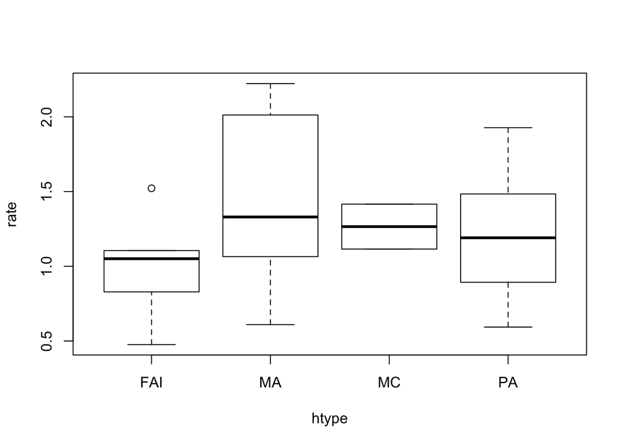

```r
plot(rate ~ htype, data = Highway1)
```

```r
Highway1$htype1 <- ifelse(Highway1$htype == 'MA','MA','NotMA')
```

To find a good model, we use best subsets regression by the package **leaps** in R, and to compare different models, we split the data into training set and testing set randomly. we use BIC criterion to choose the top three models and use the mean square error (MSE) to compare the three models further.

```r
set.seed(888)  # for reproducible results
n <- nrow(Highway1)
p <- 0.7
train <- sample(n,round(0.7*n)) # generate index to split data

hwTrain <- Highway1[train,]  # trainning set
hwTest <- Highway1[-train,]  # testing set

fit <- lm(rate ~ len + trks + sigs1 + slim + shld + acpt + htype1, data = hwTrain)
coef(fit)
```

```
## (Intercept)         len        trks       sigs1        slim        shld
##  8.00255621 -0.01613505 -0.01667327  0.07861071 -1.60211590  0.05222478
##        acpt htype1NotMA
##  0.07642102 -0.19982692
```

```r
pred <- predict(fit, newdata = hwTest)
# mean square error (MSE)
mean((pred - hwTest$rate)^2)
```

```
## [1] 0.09083979
```

```r
# Best subsets regression
md <- regsubsets(rate ~ len + trks + sigs1 + slim + shld + acpt + htype1, data = hwTrain)
out <- summary(md)
out$cp
```

```
## [1] 9.711949 2.454700 2.781102 2.918511 4.468258 6.174968 8.000000
```

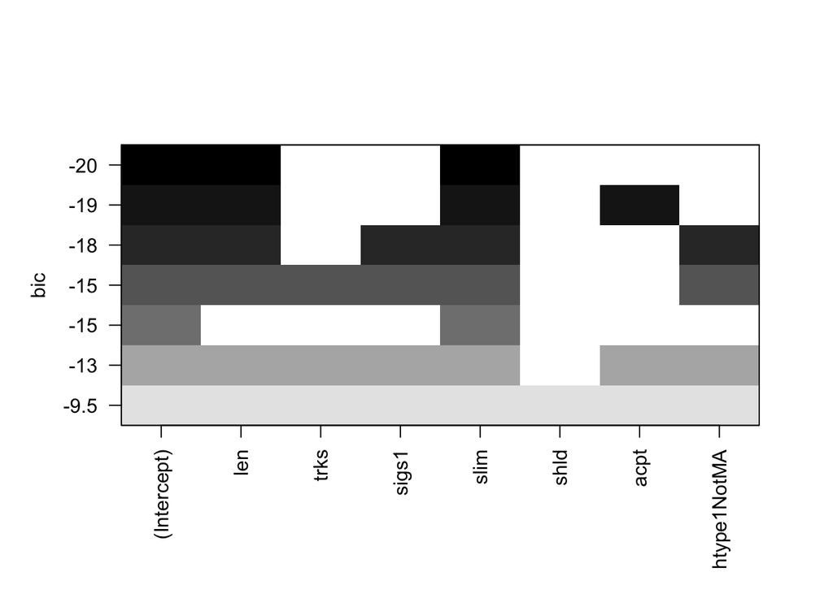

```r
# plot(md, scale = 'Cp')
plot(md, scale = 'bic')
```

```r
fit1 <- lm(rate ~ len + slim, data = hwTrain)
# coef(fit1)
fit2 <- lm(rate ~ len + sigs1 + acpt, data = hwTrain)
# coef(fit2)
fit3 <- lm(rate ~ len + sigs1 + slim + htype1, data = hwTrain)
# coef(fit3)

pred1 <- predict(fit1, newdata = hwTest)
mean((pred1 - hwTest$rate)^2)
```

```
## [1] 0.1107307
```

```r
pred2 <- predict(fit2, newdata = hwTest)
mean((pred2 - hwTest$rate)^2)
```

```
## [1] 0.08744575
```

```r
pred3 <- predict(fit3, newdata = hwTest)
mean((pred3 - hwTest$rate)^2)
```

```
## [1] 0.09653641
```

We choose the second model $rate = a_0 + a_1 len + a_2 sigs1 + a_3 acpt$, and given a significance level of 0.05, we can see that all the coefficients are significant. so the sigs1 and acpt might increse the rate and the len might decrease the rate based on the properties of positive and negative of the regression coefficients.

```r
finalmd <- lm(rate ~ len + sigs1 + acpt, data = Highway1)
summary(finalmd)
```

```
##
## Call:
## lm(formula = rate ~ len + sigs1 + acpt, data = Highway1)
##
## Residuals:
##      Min       1Q   Median       3Q      Max
## -0.64230 -0.23612  0.00606  0.22690  0.49089
##
## Coefficients:
##             Estimate Std. Error t value Pr(>|t|)
## (Intercept)  0.81958    0.22346   3.668 0.000807 ***
## len         -0.01762    0.00714  -2.468 0.018607 *
## sigs1        0.09817    0.04665   2.104 0.042597 *
## acpt         0.35453    0.07943   4.463 8.02e-05 ***
## ---
## Signif. codes:  0 '***' 0.001 '**' 0.01 '*' 0.05 '.' 0.1 ' ' 1
##
## Residual standard error: 0.2937 on 35 degrees of freedom
## Multiple R-squared:  0.6293, Adjusted R-squared:  0.5976
## F-statistic: 19.81 on 3 and 35 DF,  p-value: 1.112e-07
```

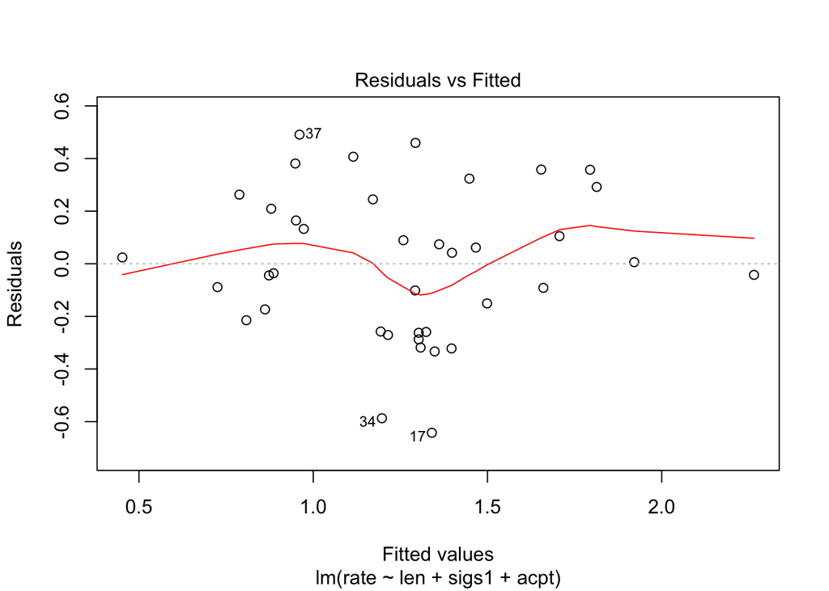

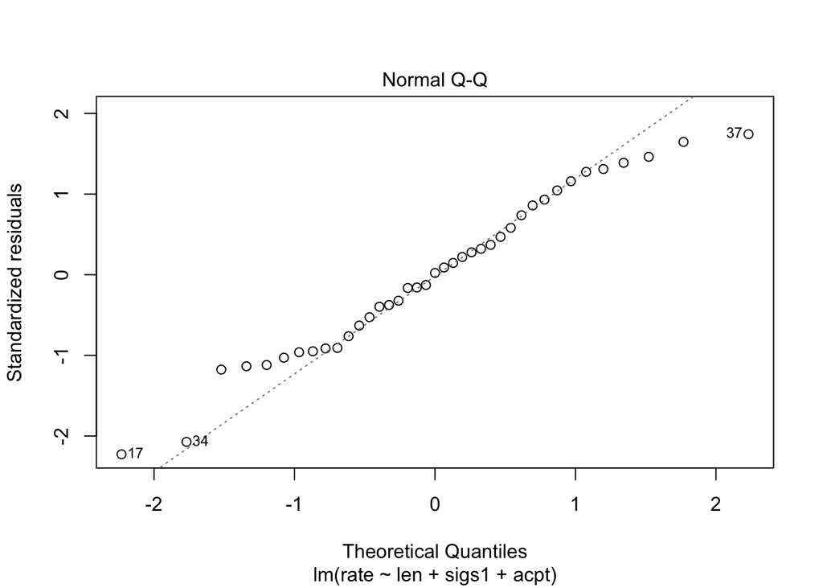

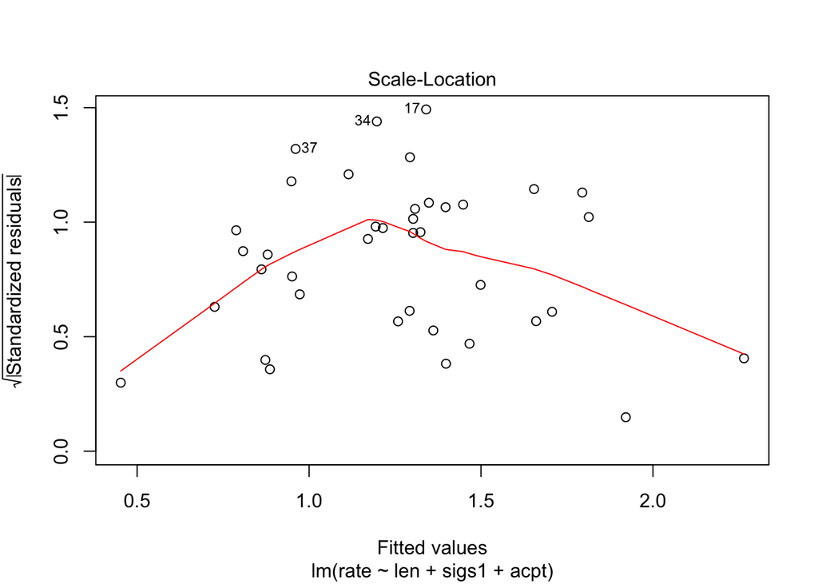

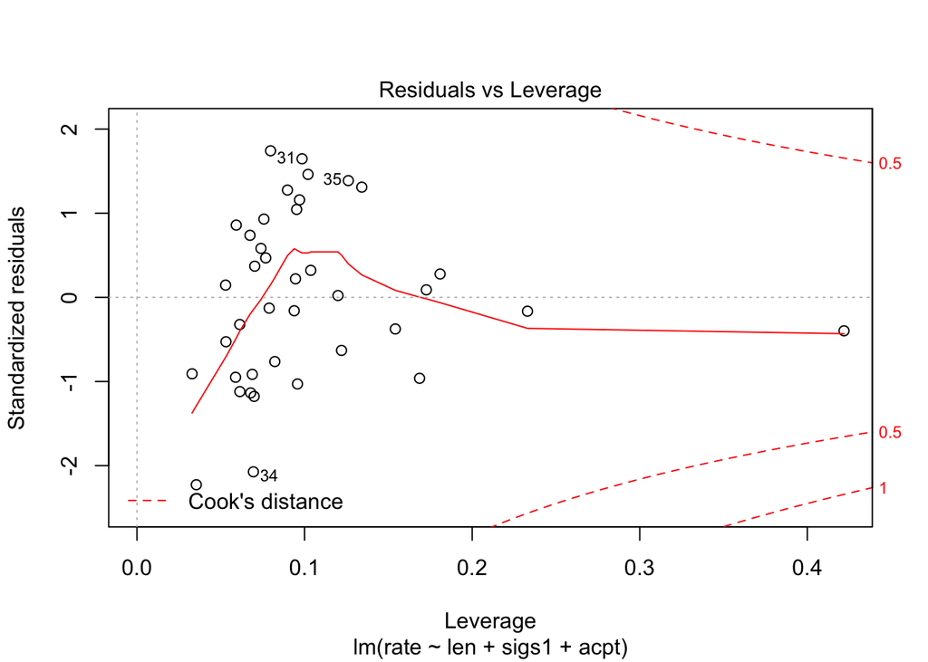

```r
plot(finalmd)
```